# Student Debt Across the USA and how does New College of Florida Students Compare Over Time (2019–2025)

### Numerical summary and histogram

```r
# summary and histogram of DEBT_MDN_SUPP goes here

current_year|>
  summarise(
    Min = min(DEBT_MDN_SUPP, na.rm = TRUE),
    Q1 = quantile(DEBT_MDN_SUPP, 0.25, na.rm = TRUE),
    Median = median(DEBT_MDN_SUPP, na.rm = TRUE),
    Q3 = quantile(DEBT_MDN_SUPP, 0.75, na.rm = TRUE),
    Max = max(DEBT_MDN_SUPP, na.rm = TRUE),
    Mean = mean(DEBT_MDN_SUPP, na.rm = TRUE),
    SD = sd(DEBT_MDN_SUPP, na.rm = TRUE),
    Total = sum(length(DEBT_MDN_SUPP)),
    Valid = sum(!is.na(DEBT_MDN_SUPP)),
    Missing = sum(is.na(DEBT_MDN_SUPP))
  )
```

| Min | Q1 | Median | Q3 | Max | Mean | SD | Total | Valid | Missing |
| --- | --- | --- | --- | --- | --- | --- | --- | --- | --- |
| 1932 | 7000 | 9500 | 15000 | 35157 | 11311.42 | 5183.688 | 6429 | 5170 | 1259 |

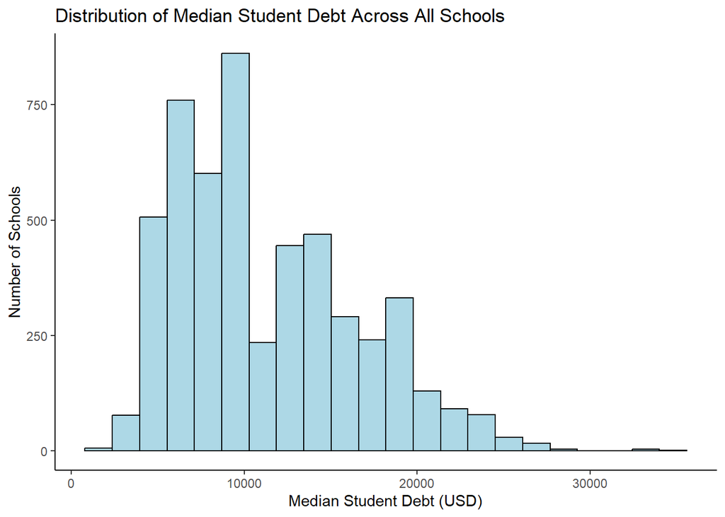

```r
ggplot(current_year, aes(x = DEBT_MDN_SUPP))+
  geom_histogram(fill = "lightblue", color = "black", bins = 22)+
  labs(
    title = "Distribution of Median Student Debt Across All Schools",
    x = " Median Student Debt (USD) ",
    y = "Number of Schools",
  )+
  theme_classic()
```

## Cost by Region in 2025

Another key question is how the cost of attending college varies depending on the region of the country. This is important because students often choose schools close to home, and costs can differ widely across regions. By comparing costs across regions we can see whether some areas consistently have more expensive schools than others. It’s also useful to consider the sample size and amount of missing data in each region.

```r
ncf_COSTT4_A <- current_year|>
  filter(isNCF == TRUE)|>
  select(COSTT4_A)
```

In the 2025 data set, the cost for NCF was 20732 (USD). This will be used as a reference line in the plot below.

### Boxplot of cost by region

The graph below shows side-by-side boxplots of the total cost of attendance for each region. The red line marks NCF’s cost for comparison.

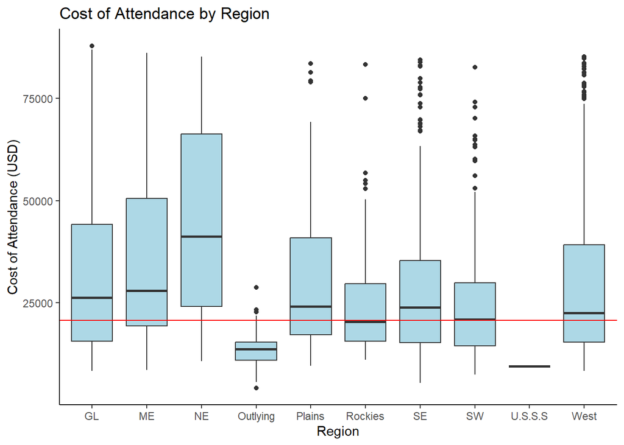

```r
# boxplot of COSTT4_A by REGION with a red line for NCF’s cost
# i decided to turn back into string category, because i think that will make easier for readers to see the comparison without having to add a key to the graph or people having to go up the report it also includes other sections where i prefer to use string key instead of numbers

reg <- current_year|>
  mutate(
    REGION = case_when(
      REGION == 0 ~ "U.S.S.S",
      REGION == 1 ~ "NE",
      REGION == 2 ~ "ME",
      REGION == 3 ~ "GL",
      REGION == 4 ~ "Plains",
      REGION == 5 ~ "SE",
      REGION == 6 ~ "SW",
      REGION == 7 ~ "Rockies",
      REGION == 8 ~ "West",
      REGION == 9 ~ "Outlying",
      TRUE ~ NA_character_
    )
  )

ggplot(reg, aes(x = REGION, y = COSTT4_A))+
  geom_boxplot(fill= 'lightblue')+
  geom_hline(yintercept = ncf_COSTT4_A[[1]], color = "red")+
  labs(
    title = "Cost of Attendance by Region",
    x = "Region" ,
    y = "Cost of Attendance (USD)"
  )+
  theme_classic()
```

### Summary of highest and lowest cost schools

The schools with the overall highest and lowest cost in 2025 were:

```r
# table showing INSTNM, REGION, COSTT4_A for the min and max schools

COSTT4_A_min_max <- reg|>
  dplyr::select(
    Institution = INSTNM,
    Region = REGION,
    `Cost of Attendance` = COSTT4_A
    )|>
  filter(
    `Cost of Attendance`== min(`Cost of Attendance`, na.rm = T) | (`Cost of Attendance` == max(`Cost of Attendance`, na.rm = T))
    )
```

| Institution | Region | Cost of Attendance |
| --- | --- | --- |
| Northwestern University | GL | 87804 |
| Instituto Tecnologico de Puerto Rico-Recinto de San Juan | Outlying | 4274 |

## Comparing Metrics by Region 2025

It is often useful to compare multiple financial measures side by side, to see whether patterns hold across different variables. In particular, we might ask whether regions that have higher costs of attendance also tend to have higher levels of debt. Here we focus on two regions with very different types of institutions: the Southeast (where NCF is located) and New England.

This question is interesting because students choosing between schools in these regions may want to know whether they are likely to graduate with similar levels of debt, or whether cost and debt behave differently depending on the region.

From a coding perspective, this section was more challenging, because the data had to be restructured so that both cost and debt could be displayed on the same plot.

### Side-by-side boxplots of cost and debt in Southeast vs New England

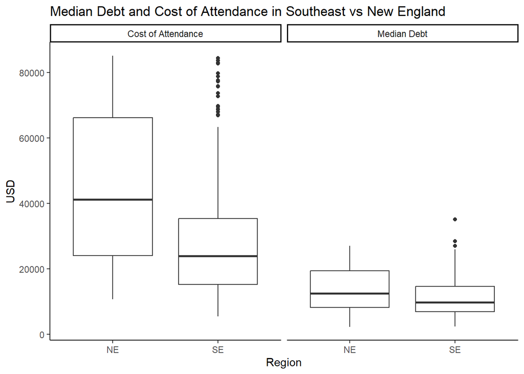

```r
# create 4 boxplots on the same graph:
# Median debt and cost of attendance for Southeast and New England regions
reg_long <- reg |>
  filter(REGION %in% c("SE", "NE")) |>
  select(
    Region = REGION,
    `Median Debt` = DEBT_MDN_SUPP,
    `Cost of Attendance` = COSTT4_A) |>
  pivot_longer(
    cols = c(`Median Debt`, `Cost of Attendance`),
    names_to = "Var_name",
    values_to = "Value"
  )

reg_long|>
  ggplot(aes(x = Region, y = Value), fill = Region)+
  geom_boxplot()+
  facet_wrap(~Var_name)+
  labs(
    title = "Median Debt and Cost of Attendance in Southeast vs New England",
    x = "Region",
    y = "USD",
    fill = "Region"
  )+
  theme_classic()
```

This concludes the report on college costs and debt.